# Observer analyses (Reported in manuscript)

Hannah, 2/19/2019

### Results are reported in manuscript

Data for Study 1 was collected in Fall 2015. Data for Study 2 was collected in Fall 2016.

**In Study 1:**  
- 101 subjects participated  
- 2 subjects’ AP data was discarded (reasons: no data because of comp malfunction, fell asleep)  
- 3 subjects’ WIT data was discarded (reasons: no data because of comp malfunction, mixed up buttons, used one response button > 85% of the time)  
*This left 99 subjects with AP data and 98 subjects with WIT data.*

**In Study 2:**  
- 206 subjects participated  
- 5 subjects’ AP data was discarded (reasons: no data because of comp malfunction [2 subjects], used one response button > 85% of the time [3 subjects])  
- 2 subjects’ WIT data was discarded (reasons: no data because of comp malfunction, used one response button > 85% of the time)  
*This left 201 subjects with AP data and 204 subjects with WIT data.*

There were 48 trials for each condition in each task (192 trials total for each task). In Study 2, each task was split into two sections so that participants could answer anxiety questions in the middle and end of each task.

### 1. Accuracy in each task:

#### 2 (Prime: Black/White) x 2 (Target: gun/tool or positive/negative) rANOVA

#### Study 1:

Only showing interaction indicating racial bias (Prime x Target). For calculation of effect sizes, see Rmarkdown file.

**WIT**

```
##                      Df Sum Sq Mean Sq F value   Pr(>F)
## PrimeType:TargetType  1  1.211  1.2114   91.35 1.21e-15 ***
## Residuals            97  1.286  0.0133
## ---
## Signif. codes:  0 '***' 0.001 '**' 0.01 '*' 0.05 '.' 0.1 ' ' 1
```

```
##      TrialType  Accuracy    TrialType        SD   ErrRate
## 1   black_tool 0.5252976   black_tool 0.1464075 0.4747024
## 2 black_weapon 0.6909014 black_weapon 0.1464822 0.3090986
## 3   white_tool 0.6426446   white_tool 0.1503013 0.3573554
## 4 white_weapon 0.5858844 white_weapon 0.1319063 0.4141156
```

**AP**

```
##                      Df Sum Sq Mean Sq F value   Pr(>F)
## PrimeType:TargetType  1 0.7697  0.7697   40.64 6.01e-09 ***
## Residuals            98 1.8560  0.0189
## ---
## Signif. codes:  0 '***' 0.001 '**' 0.01 '*' 0.05 '.' 0.1 ' ' 1
```

```
##        TrialType  Accuracy      TrialType        SD   ErrRate
## 1 black_negative 0.6081650 black_negative 0.1613654 0.3918350
## 2 black_positive 0.5652357 black_positive 0.1470626 0.4347643
## 3 white_negative 0.5258838 white_negative 0.1636929 0.4741162
## 4 white_positive 0.6593013 white_positive 0.1546850 0.3406987
```

#### Study 2:

Only showing interaction indicating racial bias (Prime x Target). For calculation of effect sizes, see Rmarkdown file.  
**WIT**

```
##                       Df Sum Sq Mean Sq F value Pr(>F)
## PrimeType:TargetType   1  1.635  1.6345   118.3 <2e-16 ***
## Residuals            203  2.804  0.0138
## ---
## Signif. codes:  0 '***' 0.001 '**' 0.01 '*' 0.05 '.' 0.1 ' ' 1
```

```
##      TrialType  Accuracy    TrialType        SD   ErrRate
## 1   black_tool 0.5555556   black_tool 0.1744104 0.4444444
## 2 black_weapon 0.6940359 black_weapon 0.1754286 0.3059641
## 3   white_tool 0.6493056   white_tool 0.1662964 0.3506944
## 4 white_weapon 0.6087623 white_weapon 0.1782526 0.3912377
```

**AP**

```
##                       Df Sum Sq Mean Sq F value   Pr(>F)
## PrimeType:TargetType   1  1.048  1.0475   53.74 5.56e-12 ***
## Residuals            200  3.899  0.0195
## ---
## Signif. codes:  0 '***' 0.001 '**' 0.01 '*' 0.05 '.' 0.1 ' ' 1
```

```
##        TrialType  Accuracy      TrialType        SD   ErrRate
## 1 black_negative 0.5819859 black_negative 0.1673953 0.4180141
## 2 black_positive 0.5828151 black_positive 0.1539756 0.4171849
## 3 white_negative 0.5117123 white_negative 0.1749347 0.4882877
## 4 white_positive 0.6569237 white_positive 0.1585664 0.3430763
```

### 2. Comparing accuracy across tasks

#### Study 1

Excludes subjects that don’t have data in both tasks (n = 97).

#### A. Correlation between performance bias scores on each task

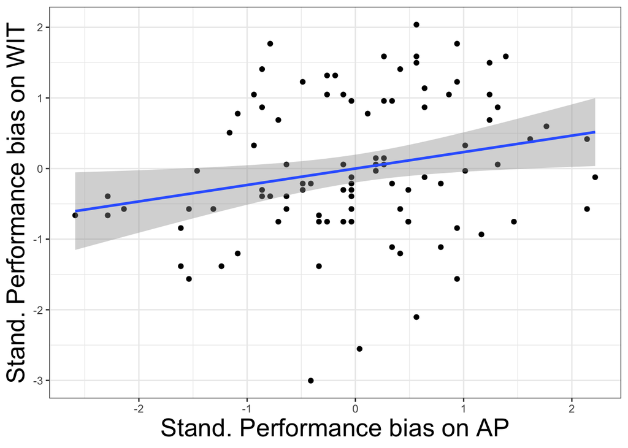

```
##
## Call:
## lm(formula = APStand ~ WITStand, data = s1.perfBias)
##
## Residuals:
##      Min       1Q   Median       3Q      Max
## -2.43376 -0.65021  0.05513  0.65317  2.27365
##
## Coefficients:
##               Estimate Std. Error t value Pr(>|t|)
## (Intercept) -1.804e-16  9.926e-02   0.000   1.0000
## WITStand     2.330e-01  9.977e-02   2.336   0.0216 *
## ---
## Signif. codes:  0 '***' 0.001 '**' 0.01 '*' 0.05 '.' 0.1 ' ' 1
##
## Residual standard error: 0.9776 on 95 degrees of freedom
## Multiple R-squared:  0.05431,    Adjusted R-squared:  0.04436
## F-statistic: 5.456 on 1 and 95 DF,  p-value: 0.02161
```

#### B. Examine 3 way Prime x Target x Task interaction

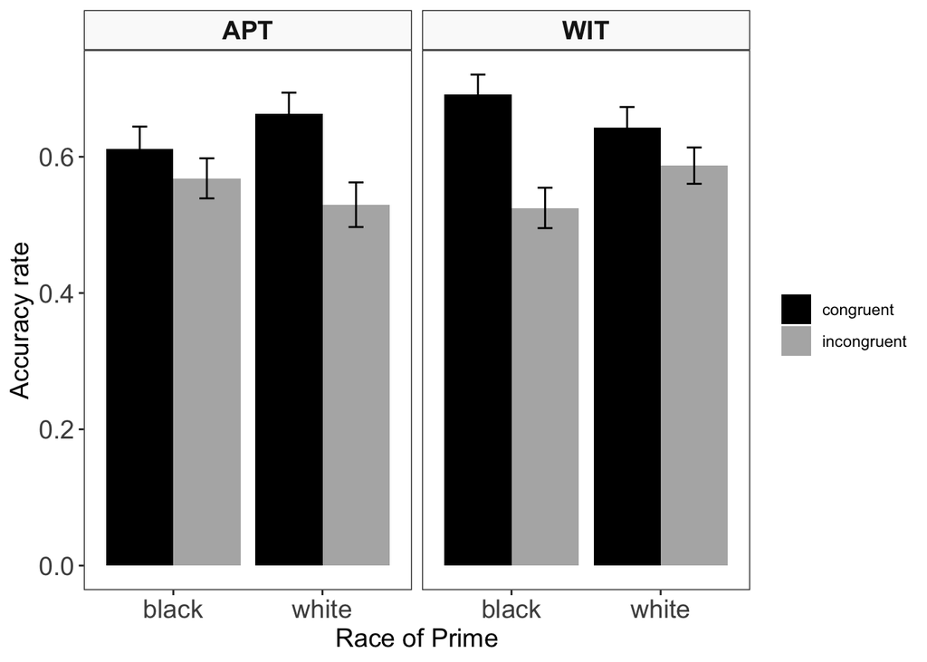

```
##                        Df Sum Sq Mean Sq F value   Pr(>F)
## PrimeType:ConType:Task  1 0.4879  0.4879   26.86 1.21e-06 ***
## Residuals              96 1.7442  0.0182
## ---
## Signif. codes:  0 '***' 0.001 '**' 0.01 '*' 0.05 '.' 0.1 ' ' 1
```

#### Study 2

Excludes subjects that don’t have data in both tasks (n = 201).

#### A. Correlation between performance bias scores on each task

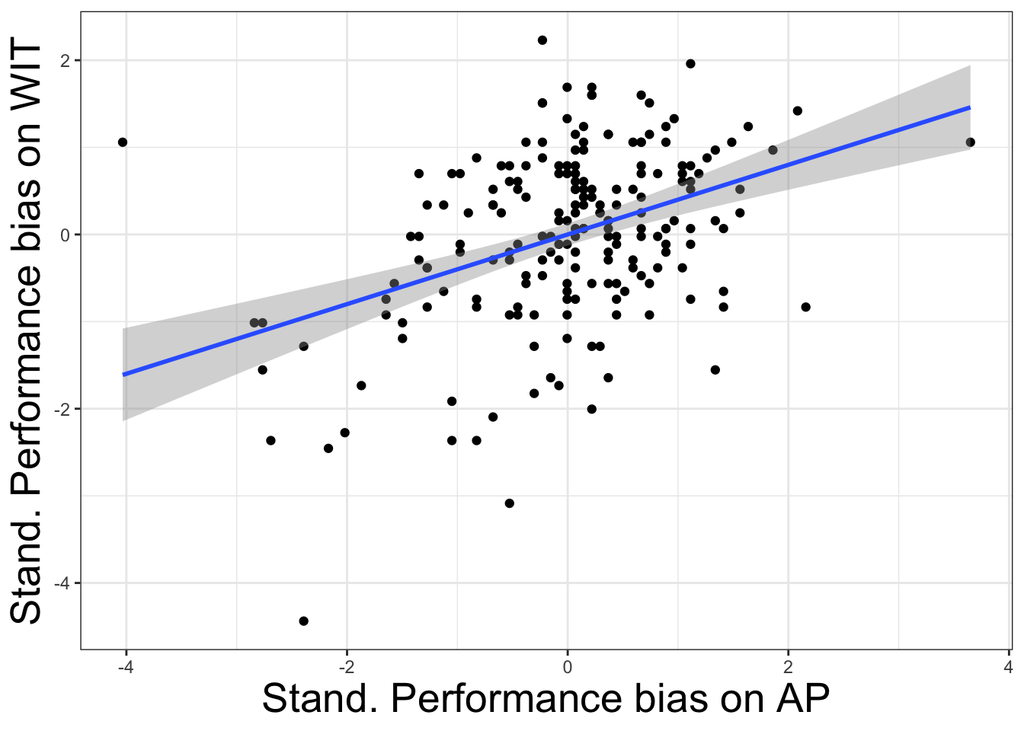

```
##
## Call:
## lm(formula = APStand ~ WITStand, data = s2.perfBias)
##
## Residuals:
##     Min      1Q  Median      3Q     Max
## -4.4572 -0.5365  0.0372  0.5929  3.2273
##
## Coefficients:
##              Estimate Std. Error t value Pr(>|t|)
## (Intercept) 5.481e-18  6.482e-02   0.000        1
## WITStand    3.997e-01  6.498e-02   6.152 4.14e-09 ***
## ---
## Signif. codes:  0 '***' 0.001 '**' 0.01 '*' 0.05 '.' 0.1 ' ' 1
##
## Residual standard error: 0.9189 on 199 degrees of freedom
## Multiple R-squared:  0.1598, Adjusted R-squared:  0.1556
## F-statistic: 37.84 on 1 and 199 DF,  p-value: 4.138e-09
```

#### B. Examine 3 way Prime x Target x Task interaction

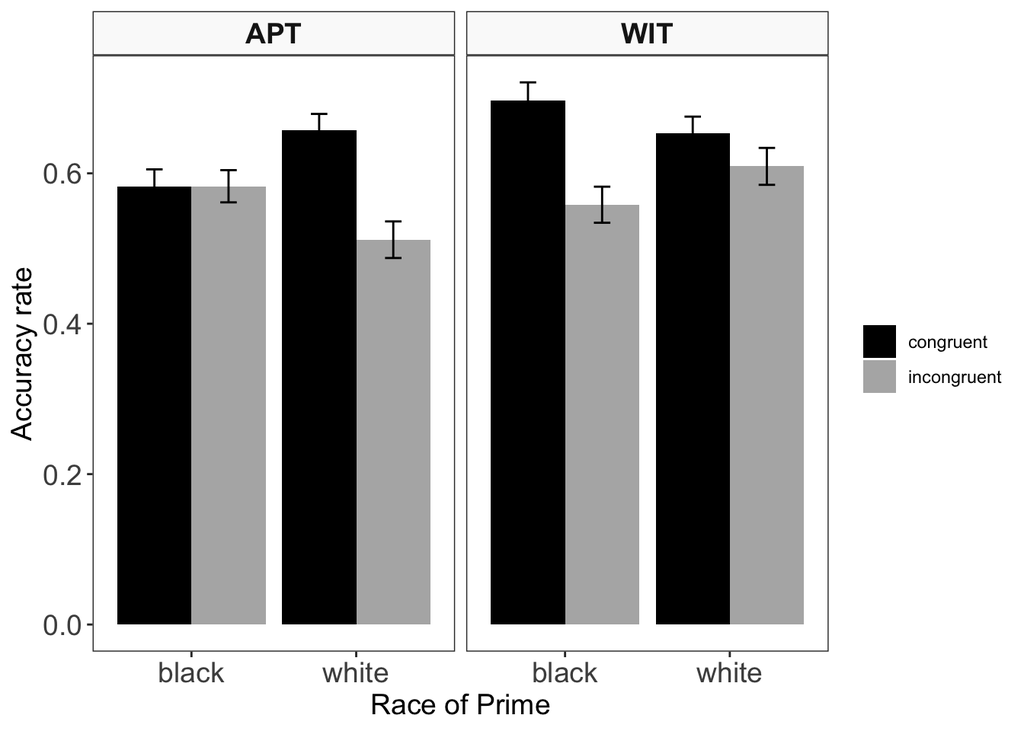

```
##                         Df Sum Sq Mean Sq F value Pr(>F)
## PrimeType:ConType:Task   1  1.458   1.458   97.32 <2e-16 ***
## Residuals              200  2.996   0.015
## ---
## Signif. codes:  0 '***' 0.001 '**' 0.01 '*' 0.05 '.' 0.1 ' ' 1
```

### 3. Correspondance in PDP estimates across tasks

Only includes data for participants with data in both tasks (N = 97). For race-specific estimate means, see Rmarkdown file.

####Study 1:

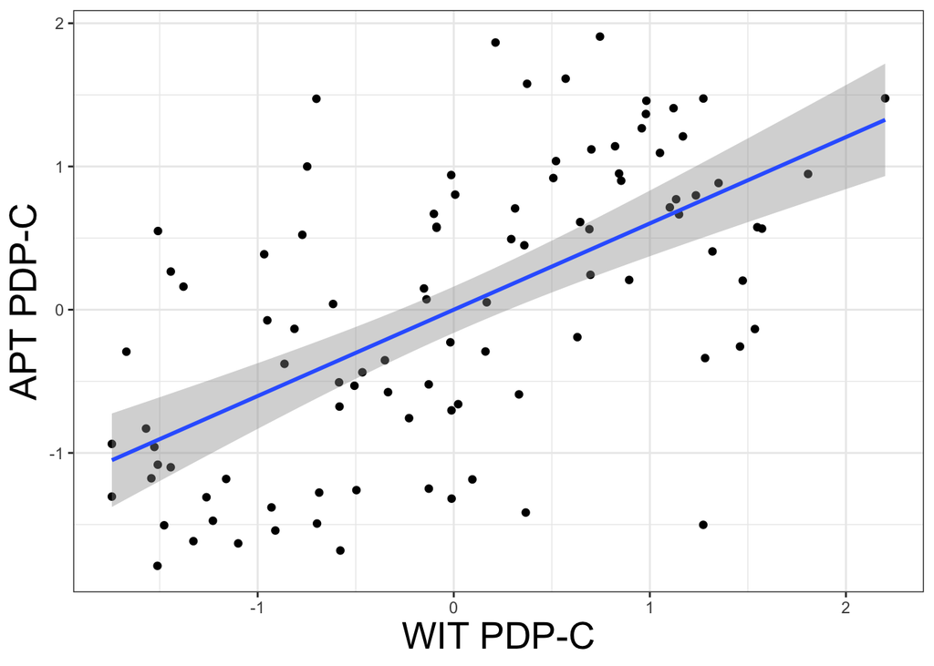

```
##
## Call:
## lm(formula = WIT.Cmean.scale ~ APT.Cmean.scale, data = s1.Cest)
##
## Residuals:
##     Min      1Q  Median      3Q     Max
## -1.8396 -0.4770  0.0189  0.4345  2.1774
##
## Coefficients:
##                   Estimate Std. Error t value Pr(>|t|)
## (Intercept)     -2.168e-16  8.146e-02   0.000        1
## APT.Cmean.scale  6.025e-01  8.188e-02   7.359 6.59e-11 ***
## ---
## Signif. codes:  0 '***' 0.001 '**' 0.01 '*' 0.05 '.' 0.1 ' ' 1
##
## Residual standard error: 0.8023 on 95 degrees of freedom
## Multiple R-squared:  0.3631, Adjusted R-squared:  0.3564
## F-statistic: 54.15 on 1 and 95 DF,  p-value: 6.591e-11
```

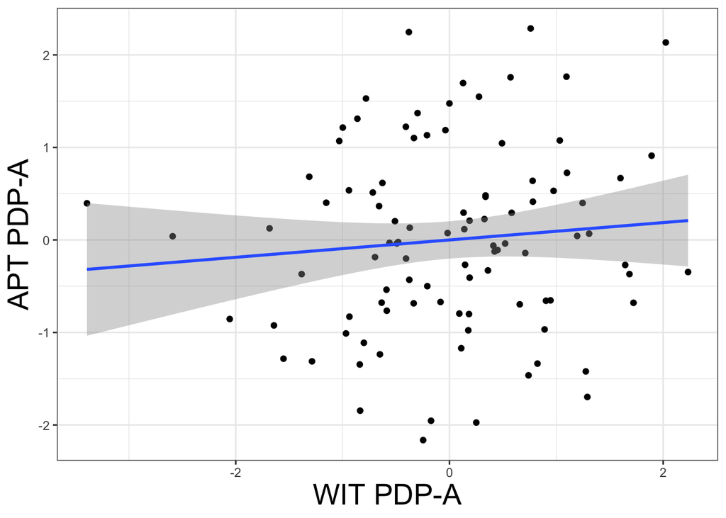

```
##
## Call:
## lm(formula = WIT.AResid.scale ~ APT.AResid.scale, data = s1.Aest)
##
## Residuals:
##     Min      1Q  Median      3Q     Max
## -3.4300 -0.5906  0.0110  0.7185  2.2657
##
## Coefficients:
##                   Estimate Std. Error t value Pr(>|t|)
## (Intercept)      8.454e-18  1.016e-01   0.000    1.000
## APT.AResid.scale 9.378e-02  1.021e-01   0.918    0.361
##
## Residual standard error: 1.001 on 95 degrees of freedom
## Multiple R-squared:  0.008796,   Adjusted R-squared:  -0.001638
## F-statistic: 0.843 on 1 and 95 DF,  p-value: 0.3609
```

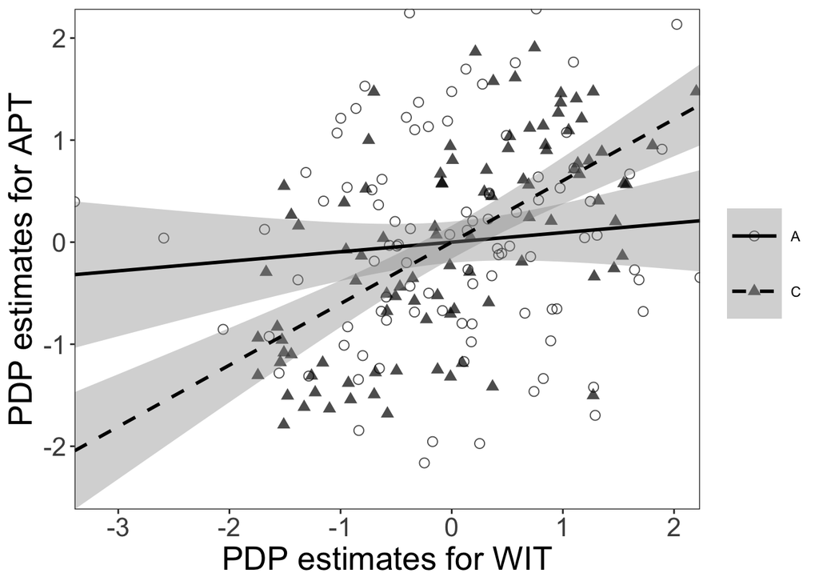

```
## lmer(formula = WIT ~ APT * EstType + (1 | Subject), data = compareAC)
```

```
##                   Estimate Std. Error        df       t value     Pr(>|t|)
## (Intercept)   8.009855e-17 0.09208313 186.36512  8.698505e-16 1.0000000000
## APT           9.190011e-02 0.09167961 186.97556  1.002405e+00 0.3174434655
## EstTypeC     -1.461984e-16 0.12065359  95.22714 -1.211720e-15 1.0000000000
## APT:EstTypeC  5.050400e-01 0.12747927 167.71930  3.961742e+00 0.0001098436
```

####Study 2:

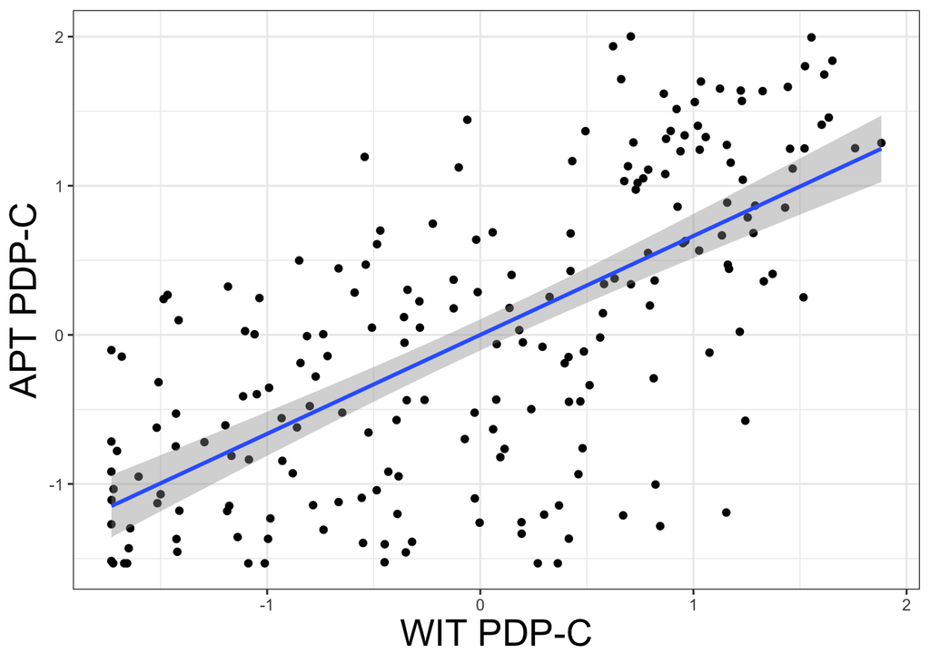

```
##
## Call:
## lm(formula = WIT.Cmean.scale ~ APT.Cmean.scale, data = s2.Cest)
##
## Residuals:
##      Min       1Q   Median       3Q      Max
## -1.66305 -0.62194  0.05257  0.56002  1.94482
##
## Coefficients:
##                  Estimate Std. Error t value Pr(>|t|)
## (Intercept)     4.940e-17  5.291e-02    0.00        1
## APT.Cmean.scale 6.635e-01  5.304e-02   12.51   <2e-16 ***
## ---
## Signif. codes:  0 '***' 0.001 '**' 0.01 '*' 0.05 '.' 0.1 ' ' 1
##
## Residual standard error: 0.7501 on 199 degrees of freedom
## Multiple R-squared:  0.4402, Adjusted R-squared:  0.4374
## F-statistic: 156.5 on 1 and 199 DF,  p-value: < 2.2e-16
```

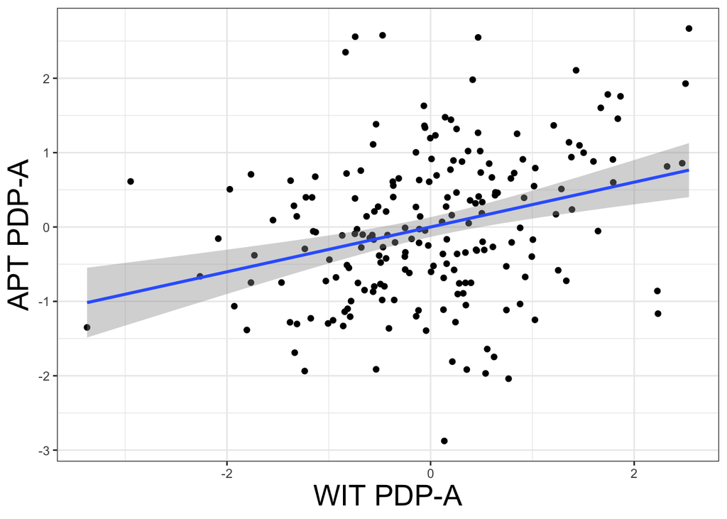

```
##
## Call:
## lm(formula = WIT.AResid.scale ~ APT.AResid.scale, data = s2.Aest)
##
## Residuals:
##      Min       1Q   Median       3Q      Max
## -3.13121 -0.55472 -0.04497  0.60261  2.58494
##
## Coefficients:
##                    Estimate Std. Error t value Pr(>|t|)
## (Intercept)      -3.658e-17  6.743e-02   0.000        1
## APT.AResid.scale  3.013e-01  6.759e-02   4.457 1.39e-05 ***
## ---
## Signif. codes:  0 '***' 0.001 '**' 0.01 '*' 0.05 '.' 0.1 ' ' 1
##
## Residual standard error: 0.9559 on 199 degrees of freedom
## Multiple R-squared:  0.09077,    Adjusted R-squared:  0.0862
## F-statistic: 19.87 on 1 and 199 DF,  p-value: 1.386e-05
```

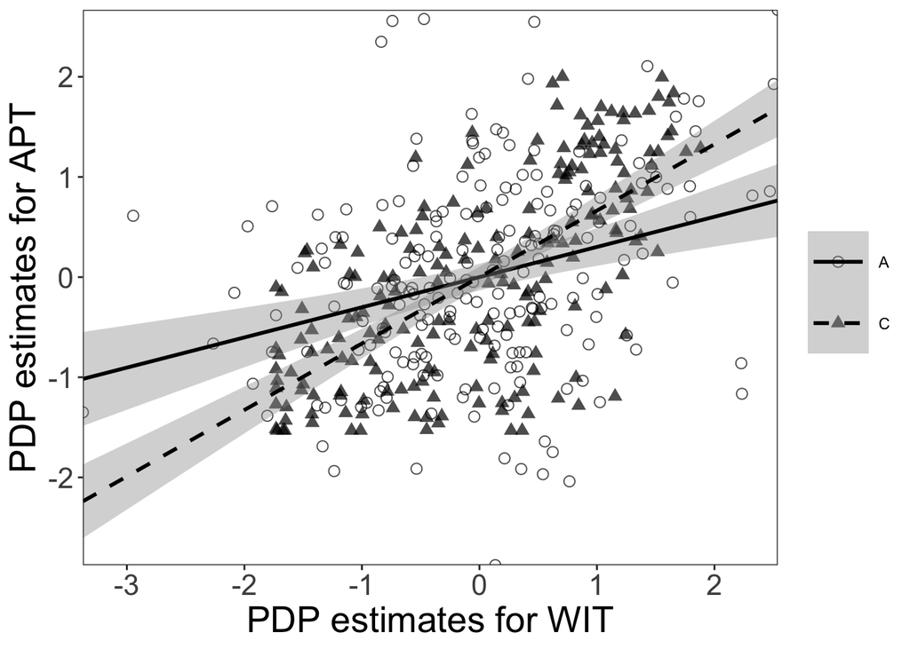

```
## lmer(formula = WIT ~ APT * EstType + (1 | Subject), data = compareAC)
```

```
##                   Estimate Std. Error       df       t value     Pr(>|t|)
## (Intercept)  -8.307188e-17 0.06060326 395.6310 -1.370749e-15 1.000000e+00
## APT           3.018658e-01 0.06057970 395.8814  4.982953e+00 9.376810e-07
## EstTypeC      4.009301e-17 0.08233724 197.1417  4.869366e-16 1.000000e+00
## APT:EstTypeC  3.516805e-01 0.08507786 373.5637  4.133632e+00 4.411951e-05
```